# Predict Bike Sharing Demand with AutoGluon Template

## Project: Predict Bike Sharing Demand with AutoGluon

This notebook is a template with each step that you need to complete for the project.

Please fill in your code where there are explicit `?` markers in the notebook. You are welcome to add more cells and code as you see fit.

Once you have completed all the code implementations, please export your notebook as a HTML file so the reviews can view your code. Make sure you have all outputs correctly outputted.

`File-> Export Notebook As... -> Export Notebook as HTML`

There is a writeup to complete as well after all code implememtation is done. Please answer all questions and attach the necessary tables and charts. You can complete the writeup in either markdown or PDF.

Completing the code template and writeup template will cover all of the rubric points for this project.

The rubric contains "Stand Out Suggestions" for enhancing the project beyond the minimum requirements. The stand out suggestions are optional. If you decide to pursue the "stand out suggestions", you can include the code in this notebook and also discuss the results in the writeup file.

## Step 1: Create an account with Kaggle

### Create Kaggle Account and download API key

Below is example of steps to get the API username and key. Each student will have their own username and key.

1. Open account settings.

2. Scroll down to API and click Create New API Token.

3. Open up `kaggle.json` and use the username and key.


## Step 2: Download the Kaggle dataset using the kaggle python library

### Open up Sagemaker Studio and use starter template

1. Notebook should be using a `ml.t3.medium` instance (2 vCPU + 4 GiB)
2. Notebook should be using kernal: `Python 3 (MXNet 1.8 Python 3.7 CPU Optimized)`

### Install packages

```python
!pip install -U pip
!pip install -U setuptools wheel
!pip install -U "mxnet<2.0.0" bokeh==2.0.1
!pip install autogluon --no-cache-dir
# Without --no-cache-dir, smaller aws instances may have trouble installing
```

[output not shown]

[output cut: 83 more lines]

[output not shown]

### Setup Kaggle API Key

```python
# create the .kaggle directory and an empty kaggle.json file
!mkdir -p /root/.kaggle
!touch /root/.kaggle/kaggle.json
!chmod 600 /root/.kaggle/kaggle.json
```

```python
# Fill in your user name and key from creating the kaggle account and API token file
import json
kaggle_username = "phamvanhanh6720"
kaggle_key = "ff1c81f4e20d78518b0aee9628705b2d"

# Save API token the kaggle.json file
with open("/root/.kaggle/kaggle.json", "w") as f:
    f.write(json.dumps({"username": kaggle_username, "key": kaggle_key}))
```

```python
!pip install kaggle
```

```
  Using cached kaggle-1.5.12-py3-none-any.whl
  Using cached python_slugify-6.1.2-py2.py3-none-any.whl (9.4 kB)
  Using cached text_unidecode-1.3-py2.py3-none-any.whl (78 kB)
WARNING: Running pip as the 'root' user can result in broken permissions and conflicting behaviour with the system package manager. It is recommended to use a virtual environment instead: https://pip.pypa.io/warnings/venv
```

### Download and explore dataset

### Go to the bike sharing demand competition and agree to the terms

```python
# Download the dataset, it will be in a .zip file so you'll need to unzip it as well.
!kaggle competitions download -c bike-sharing-demand
# If you already downloaded it you can use the -o command to overwrite the file
!unzip -o bike-sharing-demand.zip
```

```
Downloading bike-sharing-demand.zip to /root/cd0385-project-starter/project
Archive:  bike-sharing-demand.zip
  inflating: sampleSubmission.csv
  inflating: test.csv
  inflating: train.csv
```

```python
import warnings
warnings.filterwarnings("ignore")
```

```python
import pandas as pd
from autogluon.tabular import TabularPredictor
```

```python
# Create the train dataset in pandas by reading the csv
# Set the parsing of the datetime column so you can use some of the `dt` features in pandas later
train = pd.read_csv('train.csv')
train.head(5)
```

|  | datetime | season | holiday | workingday | weather | temp | atemp | humidity | windspeed | casual | registered | count |
| --- | --- | --- | --- | --- | --- | --- | --- | --- | --- | --- | --- | --- |
| 0 | 2011-01-01 00:00:00 | 1 | 0 | 0 | 1 | 9.84 | 14.395 | 81 | 0.0 | 3 | 13 | 16 |
| 1 | 2011-01-01 01:00:00 | 1 | 0 | 0 | 1 | 9.02 | 13.635 | 80 | 0.0 | 8 | 32 | 40 |
| 2 | 2011-01-01 02:00:00 | 1 | 0 | 0 | 1 | 9.02 | 13.635 | 80 | 0.0 | 5 | 27 | 32 |
| 3 | 2011-01-01 03:00:00 | 1 | 0 | 0 | 1 | 9.84 | 14.395 | 75 | 0.0 | 3 | 10 | 13 |
| 4 | 2011-01-01 04:00:00 | 1 | 0 | 0 | 1 | 9.84 | 14.395 | 75 | 0.0 | 0 | 1 | 1 |

```python
# Simple output of the train dataset to view some of the min/max/varition of the dataset features.
train.describe()
```

|  | season | holiday | workingday | weather | temp | atemp | humidity | windspeed | casual | registered | count |
| --- | --- | --- | --- | --- | --- | --- | --- | --- | --- | --- | --- |
| count | 10886.000000 | 10886.000000 | 10886.000000 | 10886.000000 | 10886.00000 | 10886.000000 | 10886.000000 | 10886.000000 | 10886.000000 | 10886.000000 | 10886.000000 |
| mean | 2.506614 | 0.028569 | 0.680875 | 1.418427 | 20.23086 | 23.655084 | 61.886460 | 12.799395 | 36.021955 | 155.552177 | 191.574132 |
| std | 1.116174 | 0.166599 | 0.466159 | 0.633839 | 7.79159 | 8.474601 | 19.245033 | 8.164537 | 49.960477 | 151.039033 | 181.144454 |
| min | 1.000000 | 0.000000 | 0.000000 | 1.000000 | 0.82000 | 0.760000 | 0.000000 | 0.000000 | 0.000000 | 0.000000 | 1.000000 |
| 25% | 2.000000 | 0.000000 | 0.000000 | 1.000000 | 13.94000 | 16.665000 | 47.000000 | 7.001500 | 4.000000 | 36.000000 | 42.000000 |
| 50% | 3.000000 | 0.000000 | 1.000000 | 1.000000 | 20.50000 | 24.240000 | 62.000000 | 12.998000 | 17.000000 | 118.000000 | 145.000000 |
| 75% | 4.000000 | 0.000000 | 1.000000 | 2.000000 | 26.24000 | 31.060000 | 77.000000 | 16.997900 | 49.000000 | 222.000000 | 284.000000 |
| max | 4.000000 | 1.000000 | 1.000000 | 4.000000 | 41.00000 | 45.455000 | 100.000000 | 56.996900 | 367.000000 | 886.000000 | 977.000000 |

```python
# Create the test pandas dataframe in pandas by reading the csv, remember to parse the datetime!
test = pd.read_csv('test.csv')
test.head()
```

|  | datetime | season | holiday | workingday | weather | temp | atemp | humidity | windspeed |
| --- | --- | --- | --- | --- | --- | --- | --- | --- | --- |
| 0 | 2011-01-20 00:00:00 | 1 | 0 | 1 | 1 | 10.66 | 11.365 | 56 | 26.0027 |
| 1 | 2011-01-20 01:00:00 | 1 | 0 | 1 | 1 | 10.66 | 13.635 | 56 | 0.0000 |
| 2 | 2011-01-20 02:00:00 | 1 | 0 | 1 | 1 | 10.66 | 13.635 | 56 | 0.0000 |
| 3 | 2011-01-20 03:00:00 | 1 | 0 | 1 | 1 | 10.66 | 12.880 | 56 | 11.0014 |
| 4 | 2011-01-20 04:00:00 | 1 | 0 | 1 | 1 | 10.66 | 12.880 | 56 | 11.0014 |

```python
# Same thing as train and test dataset
submission = pd.read_csv('sampleSubmission.csv')
submission.head()
```

|  | datetime | count |
| --- | --- | --- |
| 0 | 2011-01-20 00:00:00 | 0 |
| 1 | 2011-01-20 01:00:00 | 0 |
| 2 | 2011-01-20 02:00:00 | 0 |
| 3 | 2011-01-20 03:00:00 | 0 |
| 4 | 2011-01-20 04:00:00 | 0 |

## Step 3: Train a model using AutoGluon’s Tabular Prediction

Requirements:

- We are prediting `count`, so it is the label we are setting.
- Ignore `casual` and `registered` columns as they are also not present in the test dataset.
- Use the `root_mean_squared_error` as the metric to use for evaluation.
- Set a time limit of 10 minutes (600 seconds).
- Use the preset `best_quality` to focus on creating the best model.

```python
train.drop(['casual', 'registered'], axis=1, inplace=True)
```

```python
train.head()
```

|  | datetime | season | holiday | workingday | weather | temp | atemp | humidity | windspeed | count |
| --- | --- | --- | --- | --- | --- | --- | --- | --- | --- | --- |
| 0 | 2011-01-01 00:00:00 | 1 | 0 | 0 | 1 | 9.84 | 14.395 | 81 | 0.0 | 16 |
| 1 | 2011-01-01 01:00:00 | 1 | 0 | 0 | 1 | 9.02 | 13.635 | 80 | 0.0 | 40 |
| 2 | 2011-01-01 02:00:00 | 1 | 0 | 0 | 1 | 9.02 | 13.635 | 80 | 0.0 | 32 |
| 3 | 2011-01-01 03:00:00 | 1 | 0 | 0 | 1 | 9.84 | 14.395 | 75 | 0.0 | 13 |
| 4 | 2011-01-01 04:00:00 | 1 | 0 | 0 | 1 | 9.84 | 14.395 | 75 | 0.0 | 1 |

```python
predictor = TabularPredictor(label='count', eval_metric='root_mean_squared_error').fit(train_data=train, time_limit=600, presets='best_quality')
```

```
No path specified. Models will be saved in: "AutogluonModels/ag-20220621_162237/"
Presets specified: ['best_quality']
Beginning AutoGluon training ... Time limit = 600s
AutoGluon will save models to "AutogluonModels/ag-20220621_162237/"
AutoGluon Version:  0.4.2
Python Version:     3.7.10
Operating System:   Linux
Train Data Rows:    10886
Train Data Columns: 9
Label Column: count
Preprocessing data ...
AutoGluon infers your prediction problem is: 'regression' (because dtype of label-column == int and many unique label-values observed).
	Label info (max, min, mean, stddev): (977, 1, 191.57413, 181.14445)
	If 'regression' is not the correct problem_type, please manually specify the problem_type parameter during predictor init (You may specify problem_type as one of: ['binary', 'multiclass', 'regression'])
Using Feature Generators to preprocess the data ...
Fitting AutoMLPipelineFeatureGenerator...
	Available Memory:                    3077.52 MB
	Train Data (Original)  Memory Usage: 1.52 MB (0.0% of available memory)
	Inferring data type of each feature based on column values. Set feature_metadata_in to manually specify special dtypes of the features.
	Stage 1 Generators:
		Fitting AsTypeFeatureGenerator...
			Note: Converting 2 features to boolean dtype as they only contain 2 unique values.
	Stage 2 Generators:
		Fitting FillNaFeatureGenerator...
	Stage 3 Generators:
		Fitting IdentityFeatureGenerator...
		Fitting DatetimeFeatureGenerator...
	Stage 4 Generators:
		Fitting DropUniqueFeatureGenerator...
	Types of features in original data (raw dtype, special dtypes):
		('float', [])                      : 3 | ['temp', 'atemp', 'windspeed']
		('int', [])                        : 5 | ['season', 'holiday', 'workingday', 'weather', 'humidity']
		('object', ['datetime_as_object']) : 1 | ['datetime']
	Types of features in processed data (raw dtype, special dtypes):
		('float', [])                : 3 | ['temp', 'atemp', 'windspeed']
		('int', [])                  : 3 | ['season', 'weather', 'humidity']
		('int', ['bool'])            : 2 | ['holiday', 'workingday']
		('int', ['datetime_as_int']) : 5 | ['datetime', 'datetime.year', 'datetime.month', 'datetime.day', 'datetime.dayofweek']
	0.1s = Fit runtime
	9 features in original data used to generate 13 features in processed data.
```

[output cut: 69 more lines]

```
	-53.8372	 = Validation score   (root_mean_squared_error)
	8.0s	 = Training   runtime
	0.58s	 = Validation runtime
Fitting model: NeuralNetFastAI_BAG_L2 ... Training model for up to 7.93s of the 7.91s of remaining time.
	Fitting 8 child models (S1F1 - S1F8) | Fitting with ParallelLocalFoldFittingStrategy
	-89.1703	 = Validation score   (root_mean_squared_error)
	26.36s	 = Training   runtime
	0.46s	 = Validation runtime
Completed 1/20 k-fold bagging repeats ...
Fitting model: WeightedEnsemble_L3 ... Training model for up to 360.0s of the -21.26s of remaining time.
	-52.8395	 = Validation score   (root_mean_squared_error)
	0.56s	 = Training   runtime
	0.0s	 = Validation runtime
AutoGluon training complete, total runtime = 622.09s ... Best model: "WeightedEnsemble_L3"
TabularPredictor saved. To load, use: predictor = TabularPredictor.load("AutogluonModels/ag-20220621_162237/")
```

### Review AutoGluon's training run with ranking of models that did the best.

```python
result = predictor.leaderboard(s)
result
```

```
                     model   score_val  pred_time_val    fit_time  pred_time_val_marginal  fit_time_marginal  stack_level  can_infer  fit_order
0      WeightedEnsemble_L3  -52.839546      10.935707  500.988049                0.001121           0.558667            3       True         16
1   RandomForestMSE_BAG_L2  -53.420993      10.016516  405.412109                0.590401          25.617151            2       True         12
2     ExtraTreesMSE_BAG_L2  -53.837247      10.002940  387.793744                0.576825           7.998786            2       True         14
3          LightGBM_BAG_L2  -55.139801       9.679110  401.327850                0.252995          21.532892            2       True         11
4          CatBoost_BAG_L2  -55.575815       9.514364  445.280552                0.088249          65.485595            2       True         13
5        LightGBMXT_BAG_L2  -60.487971      12.274344  426.479515                2.848229          46.684557            2       True         10
6    KNeighborsDist_BAG_L1  -84.125061       0.103578    0.029261                0.103578           0.029261            1       True          2
7      WeightedEnsemble_L2  -84.125061       0.104340    0.749152                0.000762           0.719891            2       True          9
8   NeuralNetFastAI_BAG_L2  -89.170309       9.890927  406.153797                0.464812          26.358839            2       True         15
9    KNeighborsUnif_BAG_L1 -101.546199       0.102797    0.033739                0.102797           0.033739            1       True          1
10  RandomForestMSE_BAG_L1 -116.544294       0.521307   10.238525                0.521307          10.238525            1       True          5
11    ExtraTreesMSE_BAG_L1 -124.588053       0.519322    4.939990                0.519322           4.939990            1       True          7
12         CatBoost_BAG_L1 -130.494282       0.145838  198.097067                0.145838         198.097067            1       True          6
13         LightGBM_BAG_L1 -131.054162       1.456013   26.234932                1.456013          26.234932            1       True          4
14       LightGBMXT_BAG_L1 -131.460909       6.149294   60.574657                6.149294          60.574657            1       True          3
15  NeuralNetFastAI_BAG_L1 -136.699702       0.427966   79.646786                0.427966          79.646786            1       True          8
```

|  | model | score_val | pred_time_val | fit_time | pred_time_val_marginal | fit_time_marginal | stack_level | can_infer | fit_order |
| --- | --- | --- | --- | --- | --- | --- | --- | --- | --- |
| 0 | WeightedEnsemble_L3 | -52.839546 | 10.935707 | 500.988049 | 0.001121 | 0.558667 | 3 | True | 16 |
| 1 | RandomForestMSE_BAG_L2 | -53.420993 | 10.016516 | 405.412109 | 0.590401 | 25.617151 | 2 | True | 12 |
| 2 | ExtraTreesMSE_BAG_L2 | -53.837247 | 10.002940 | 387.793744 | 0.576825 | 7.998786 | 2 | True | 14 |
| 3 | LightGBM_BAG_L2 | -55.139801 | 9.679110 | 401.327850 | 0.252995 | 21.532892 | 2 | True | 11 |
| 4 | CatBoost_BAG_L2 | -55.575815 | 9.514364 | 445.280552 | 0.088249 | 65.485595 | 2 | True | 13 |
| 5 | LightGBMXT_BAG_L2 | -60.487971 | 12.274344 | 426.479515 | 2.848229 | 46.684557 | 2 | True | 10 |
| 6 | KNeighborsDist_BAG_L1 | -84.125061 | 0.103578 | 0.029261 | 0.103578 | 0.029261 | 1 | True | 2 |
| 7 | WeightedEnsemble_L2 | -84.125061 | 0.104340 | 0.749152 | 0.000762 | 0.719891 | 2 | True | 9 |
| 8 | NeuralNetFastAI_BAG_L2 | -89.170309 | 9.890927 | 406.153797 | 0.464812 | 26.358839 | 2 | True | 15 |
| 9 | KNeighborsUnif_BAG_L1 | -101.546199 | 0.102797 | 0.033739 | 0.102797 | 0.033739 | 1 | True | 1 |
| 10 | RandomForestMSE_BAG_L1 | -116.544294 | 0.521307 | 10.238525 | 0.521307 | 10.238525 | 1 | True | 5 |
| 11 | ExtraTreesMSE_BAG_L1 | -124.588053 | 0.519322 | 4.939990 | 0.519322 | 4.939990 | 1 | True | 7 |
| 12 | CatBoost_BAG_L1 | -130.494282 | 0.145838 | 198.097067 | 0.145838 | 198.097067 | 1 | True | 6 |
| 13 | LightGBM_BAG_L1 | -131.054162 | 1.456013 | 26.234932 | 1.456013 | 26.234932 | 1 | True | 4 |
| 14 | LightGBMXT_BAG_L1 | -131.460909 | 6.149294 | 60.574657 | 6.149294 | 60.574657 | 1 | True | 3 |
| 15 | NeuralNetFastAI_BAG_L1 | -136.699702 | 0.427966 | 79.646786 | 0.427966 | 79.646786 | 1 | True | 8 |

```
(array([-2.,  0.,  2.,  4.,  6.,  8., 10., 12., 14., 16.]),
 [Text(-2.0, 0, 'LightGBMXT_BAG_L1'),
```

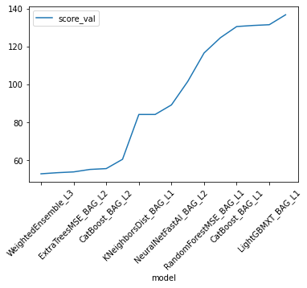

```python
# performance comparision
import matplotlib.pyplot as plt

result['score_val'] = result['score_val'].apply(func=lambda x: -x)

result.plot.line(x='model', y='score_val' )
plt.xticks(rotation=45)
```

### Create predictions from test dataset

```python
predictions = predictor.predict(test)
predictions.head()
```

```
0    22.311737
1    41.621101
2    45.338188
3    48.606998
4    51.610649
Name: count, dtype: float32
```

```python
submission = predictions.to_frame()
```

#### NOTE: Kaggle will reject the submission if we don't set everything to be > 0.

```python
# Describe the `predictions` series to see if there are any negative values
submission['datetime'] = test['datetime']
```

```python
submission = submission[['datetime', 'count']]
```

```python
submission.head()
```

|  | datetime | count |
| --- | --- | --- |
| 0 | 2011-01-20 00:00:00 | 22.311737 |
| 1 | 2011-01-20 01:00:00 | 41.621101 |
| 2 | 2011-01-20 02:00:00 | 45.338188 |
| 3 | 2011-01-20 03:00:00 | 48.606998 |
| 4 | 2011-01-20 04:00:00 | 51.610649 |

```python
# How many negative values do we have?
num_negative = len(submission[submission['count'] < 0])
num_negative
```

```
0
```

### Set predictions to submission dataframe, save, and submit

```python
# submission["count"] = ?
submission.to_csv("submission.csv", index=False)
```

```python
!kaggle competitions submit -c bike-sharing-demand -f submission.csv -m "first raw submission"
```

```
Successfully submitted to Bike Sharing Demand
```

#### View submission via the command line or in the web browser under the competition's page - `My Submissions`

```python
!kaggle competitions submissions -c bike-sharing-demand | tail -n +1 | head -n 6
```

[output not shown]

## Step 4: Exploratory Data Analysis and Creating an additional feature

- Any additional feature will do, but a great suggestion would be to separate out the datetime into hour, day, or month parts.

```python
train.head()
```

|  | datetime | season | holiday | workingday | weather | temp | atemp | humidity | windspeed | count |
| --- | --- | --- | --- | --- | --- | --- | --- | --- | --- | --- |
| 0 | 2011-01-01 00:00:00 | 1 | 0 | 0 | 1 | 9.84 | 14.395 | 81 | 0.0 | 16 |
| 1 | 2011-01-01 01:00:00 | 1 | 0 | 0 | 1 | 9.02 | 13.635 | 80 | 0.0 | 40 |
| 2 | 2011-01-01 02:00:00 | 1 | 0 | 0 | 1 | 9.02 | 13.635 | 80 | 0.0 | 32 |
| 3 | 2011-01-01 03:00:00 | 1 | 0 | 0 | 1 | 9.84 | 14.395 | 75 | 0.0 | 13 |
| 4 | 2011-01-01 04:00:00 | 1 | 0 | 0 | 1 | 9.84 | 14.395 | 75 | 0.0 | 1 |

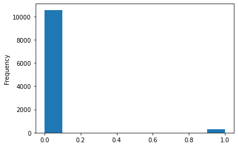

```python
# Create a histogram of all features to show the distribution of each one relative to the data. This is part of the exploritory data analysis
import matplotlib.pyplot as plt

train['holiday'].plot.hist()
plt.show()
```

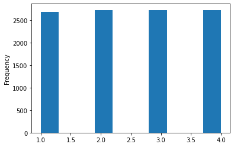

```python
train['season'].plot.hist()
plt.show()
```

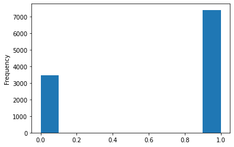

```python
train['workingday'].plot.hist()
plt.show()
```

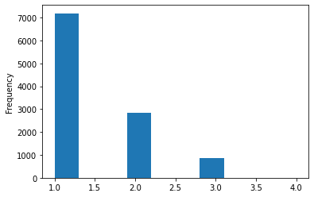

```python
train['weather'].plot.hist()
plt.show()
```

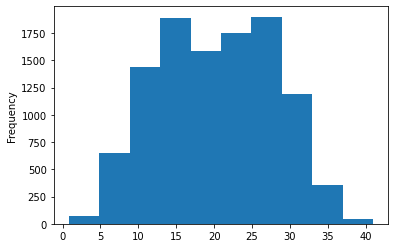

```python
train['temp'].plot.hist()
plt.show()
```

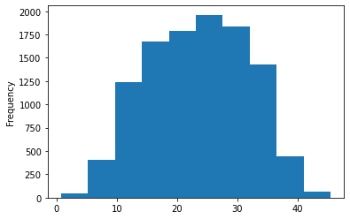

```python
train['atemp'].plot.hist()
plt.show()
```

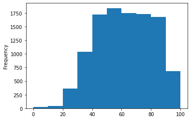

```python
train['humidity'].plot.hist()
plt.show()
```

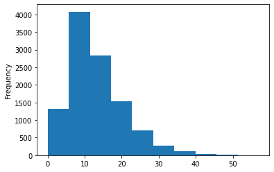

```python
train['windspeed'].plot.hist()
plt.show()
```

```python
from datetime import datetime

def create_new_features(df):
    df["date"] = df['datetime'].apply(lambda x : x.split()[0])
    df["hour"] = df['datetime'].apply(lambda x : x.split()[1].split(":")[0]).astype("int")
    df["year"] = df['datetime'].apply(lambda x : x.split()[0].split("-")[0])
    df["weekday"] = df['date'].apply(lambda x : datetime.strptime(x,"%Y-%m-%d").weekday())
    df["month"] = df['date'].apply(lambda x : datetime.strptime(x,"%Y-%m-%d").month)

    return df
```

```python
# create a new feature
new_train = create_new_features(train)
new_test = create_new_features(test)
```

## Make category types for these so models know they are not just numbers

- AutoGluon originally sees these as ints, but in reality they are int representations of a category.
- Setting the dtype to category will classify these as categories in AutoGluon.

```python
new_train["season"] = new_train['season'].map({1: "Spring", 2 : "Summer", 3 : "Fall", 4 :"Winter" })
new_train["weather"] = new_train['weather'].map({1: " Clear + Few clouds + Partly cloudy + Partly cloudy",\
                                        2 : " Mist + Cloudy, Mist + Broken clouds, Mist + Few clouds, Mist ", \
                                        3 : " Light Snow, Light Rain + Thunderstorm + Scattered clouds, Light Rain + Scattered clouds", \
                                        4 :" Heavy Rain + Ice Pallets + Thunderstorm + Mist, Snow + Fog " })
new_test["season"] = new_test['season'].map({1: "Spring", 2 : "Summer", 3 : "Fall", 4 :"Winter" })
new_test["weather"] = new_test['weather'].map({1: " Clear + Few clouds + Partly cloudy + Partly cloudy",\
                                        2 : " Mist + Cloudy, Mist + Broken clouds, Mist + Few clouds, Mist ", \
                                        3 : " Light Snow, Light Rain + Thunderstorm + Scattered clouds, Light Rain + Scattered clouds", \
                                        4 :" Heavy Rain + Ice Pallets + Thunderstorm + Mist, Snow + Fog " })
```

```python
categorical_features = ["hour","weekday","month","season","weather","holiday","workingday"]
drop_features = ['datetime', 'date', 'year']

for feature in categorical_features:
    new_train[feature] = new_train[feature].astype('category')
    new_test[feature] = new_test[feature].astype('category')
```

```python
new_train.drop(drop_features, axis=1, inplace=True)
```

```python
new_test.drop(drop_features, axis=1, inplace=True)
```

```python
# View are new feature
new_train.head()
```

|  | season | holiday | workingday | weather | temp | atemp | humidity | windspeed | count | hour | weekday | month |
| --- | --- | --- | --- | --- | --- | --- | --- | --- | --- | --- | --- | --- |
| 0 | Spring | 0 | 0 | Clear + Few clouds + Partly cloudy + Partly c... | 9.84 | 14.395 | 81 | 0.0 | 16 | 0 | 5 | 1 |
| 1 | Spring | 0 | 0 | Clear + Few clouds + Partly cloudy + Partly c... | 9.02 | 13.635 | 80 | 0.0 | 40 | 1 | 5 | 1 |
| 2 | Spring | 0 | 0 | Clear + Few clouds + Partly cloudy + Partly c... | 9.02 | 13.635 | 80 | 0.0 | 32 | 2 | 5 | 1 |
| 3 | Spring | 0 | 0 | Clear + Few clouds + Partly cloudy + Partly c... | 9.84 | 14.395 | 75 | 0.0 | 13 | 3 | 5 | 1 |
| 4 | Spring | 0 | 0 | Clear + Few clouds + Partly cloudy + Partly c... | 9.84 | 14.395 | 75 | 0.0 | 1 | 4 | 5 | 1 |

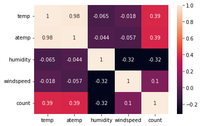

```python
# View histogram of all features again now with the hour feature
import pandas as pd
import seaborn as sn
import matplotlib.pyplot as plt


# correlation coefficient chart
corrMatrix = new_train.corr()
sn.heatmap(corrMatrix, annot=True)
plt.show()
```

## Step 5: Rerun the model with the same settings as before, just with more features

```python
new_train.dtypes
```

```
season        category
holiday       category
workingday    category
weather       category
temp           float64
atemp          float64
humidity         int64
windspeed      float64
count            int64
hour          category
weekday       category
month         category
dtype: object
```

```python
predictor_new_features = TabularPredictor(label='count', eval_metric='root_mean_squared_error').fit(train_data=new_train, time_limit=600, presets='best_quality')
```

```
No path specified. Models will be saved in: "AutogluonModels/ag-20220621_164045/"
Presets specified: ['best_quality']
Beginning AutoGluon training ... Time limit = 600s
AutoGluon will save models to "AutogluonModels/ag-20220621_164045/"
AutoGluon Version:  0.4.2
Python Version:     3.7.10
Operating System:   Linux
Train Data Rows:    10886
Train Data Columns: 11
Label Column: count
Preprocessing data ...
AutoGluon infers your prediction problem is: 'regression' (because dtype of label-column == int and many unique label-values observed).
	Label info (max, min, mean, stddev): (977, 1, 191.57413, 181.14445)
	If 'regression' is not the correct problem_type, please manually specify the problem_type parameter during predictor init (You may specify problem_type as one of: ['binary', 'multiclass', 'regression'])
Using Feature Generators to preprocess the data ...
Fitting AutoMLPipelineFeatureGenerator...
	Available Memory:                    2467.99 MB
	Train Data (Original)  Memory Usage: 0.43 MB (0.0% of available memory)
	Inferring data type of each feature based on column values. Set feature_metadata_in to manually specify special dtypes of the features.
	Stage 1 Generators:
		Fitting AsTypeFeatureGenerator...
			Note: Converting 2 features to boolean dtype as they only contain 2 unique values.
	Stage 2 Generators:
		Fitting FillNaFeatureGenerator...
	Stage 3 Generators:
		Fitting IdentityFeatureGenerator...
		Fitting CategoryFeatureGenerator...
			Fitting CategoryMemoryMinimizeFeatureGenerator...
	Stage 4 Generators:
		Fitting DropUniqueFeatureGenerator...
	Types of features in original data (raw dtype, special dtypes):
		('category', []) : 7 | ['season', 'holiday', 'workingday', 'weather', 'hour', ...]
		('float', [])    : 3 | ['temp', 'atemp', 'windspeed']
		('int', [])      : 1 | ['humidity']
	Types of features in processed data (raw dtype, special dtypes):
		('category', [])  : 5 | ['season', 'weather', 'hour', 'weekday', 'month']
		('float', [])     : 3 | ['temp', 'atemp', 'windspeed']
		('int', [])       : 1 | ['humidity']
		('int', ['bool']) : 2 | ['holiday', 'workingday']
	0.1s = Fit runtime
```

[output cut: 73 more lines]

```
	-58.3819	 = Validation score   (root_mean_squared_error)
	7.25s	 = Training   runtime
	0.6s	 = Validation runtime
Fitting model: NeuralNetFastAI_BAG_L2 ... Training model for up to 20.46s of the 20.45s of remaining time.
	Fitting 8 child models (S1F1 - S1F8) | Fitting with ParallelLocalFoldFittingStrategy
	-59.4453	 = Validation score   (root_mean_squared_error)
	36.06s	 = Training   runtime
	0.59s	 = Validation runtime
Completed 1/20 k-fold bagging repeats ...
Fitting model: WeightedEnsemble_L3 ... Training model for up to 360.0s of the -18.83s of remaining time.
	-58.1547	 = Validation score   (root_mean_squared_error)
	0.57s	 = Training   runtime
	0.0s	 = Validation runtime
AutoGluon training complete, total runtime = 619.63s ... Best model: "WeightedEnsemble_L3"
TabularPredictor saved. To load, use: predictor = TabularPredictor.load("AutogluonModels/ag-20220621_164045/")
```

```python
result = predictor_new_features.leaderboard()
```

```
                     model   score_val  pred_time_val    fit_time  pred_time_val_marginal  fit_time_marginal  stack_level  can_infer  fit_order
0      WeightedEnsemble_L3  -58.154650      10.336370  516.451313                0.001116           0.571766            3       True         16
1     ExtraTreesMSE_BAG_L2  -58.381918       9.573817  401.955878                0.596636           7.251462            2       True         14
2          CatBoost_BAG_L2  -58.718704       9.151016  472.571805                0.173834          77.867389            2       True         13
3      WeightedEnsemble_L2  -58.940337       7.586005  338.752469                0.001189           0.737819            2       True          9
4          LightGBM_BAG_L2  -59.298472       9.128470  414.246496                0.151288          19.542080            2       True         11
5   RandomForestMSE_BAG_L2  -59.415098       9.577174  419.556642                0.599992          24.852226            2       True         12
6   NeuralNetFastAI_BAG_L2  -59.445278       9.564783  430.760696                0.587602          36.056280            2       True         15
7        LightGBMXT_BAG_L2  -60.170001       9.191991  414.098693                0.214809          19.394277            2       True         10
8          LightGBM_BAG_L1  -60.205634       2.350748   32.525478                2.350748          32.525478            1       True          4
9        LightGBMXT_BAG_L1  -60.835790       4.146831   42.780896                4.146831          42.780896            1       True          3
10         CatBoost_BAG_L1  -62.699204       0.521164  253.982665                0.521164         253.982665            1       True          6
11    ExtraTreesMSE_BAG_L1  -64.360367       0.550483    4.568451                0.550483           4.568451            1       True          7
12  RandomForestMSE_BAG_L1  -64.394802       0.566073    8.725611                0.566073           8.725611            1       True          5
13  NeuralNetFastAI_BAG_L1  -65.774283       0.633590   52.087354                0.633590          52.087354            1       True          8
14   KNeighborsUnif_BAG_L1 -164.557615       0.103163    0.017051                0.103163           0.017051            1       True          1
15   KNeighborsDist_BAG_L1 -179.009302       0.105130    0.016909                0.105130           0.016909            1       True          2
```

```
(array([-2.,  0.,  2.,  4.,  6.,  8., 10., 12., 14., 16.]),
 [Text(-2.0, 0, 'KNeighborsUnif_BAG_L1'),
```

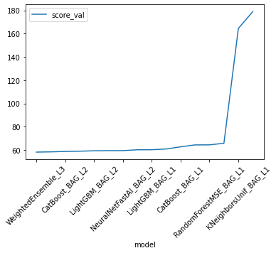

```python
# performance comparision
import matplotlib.pyplot as plt

result['score_val'] = result['score_val'].apply(func=lambda x: -x)

result.plot.line(x='model', y='score_val' )
plt.xticks(rotation=45)
```

```python
# Remember to set all negative values to zero
predictions = predictor_new_features.predict(new_test)
```

```python
submission_new_features = predictions.to_frame()
```

```python
submission_new_features.head()
```

[output not shown]

```python
submission_new_features['datetime'] = test['datetime']
```

```python
submission_new_features = submission_new_features[['datetime', 'count']]
```

```python
# Same submitting predictions
submission_new_features.to_csv("submission_new_features.csv", index=False)
```

```python
!kaggle competitions submit -c bike-sharing-demand -f submission_new_features.csv -m "new features"
```

```
Successfully submitted to Bike Sharing Demand
```

```python
!kaggle competitions submissions -c bike-sharing-demand | tail -n +1 | head -n 6
```

[output not shown]

## Step 6: Hyper parameter optimization

- There are many options for hyper parameter optimization.
- Options are to change the AutoGluon higher level parameters or the individual model hyperparameters.
- The hyperparameters of the models themselves that are in AutoGluon. Those need the `hyperparameter` and `hyperparameter_tune_kwargs` arguments.

```python
time_limit = 600
num_trials = 5

hyperparameters = 'very_light'

search_strategy = 'random'
hyperparameter_tune_kwargs = {
    'num_trials': num_trials,
    'scheduler' : 'local',
    'searcher': search_strategy
}
```

```python
predictor_new_hpo = TabularPredictor(label='count', eval_metric='root_mean_squared_error').fit(train_data=new_train, time_limit=time_limit, presets='best_quality', hyperparameters=hyperparameters,hyperparameter_tune_kwargs=hyperparameter_tune_kwargs)
```

```
No path specified. Models will be saved in: "AutogluonModels/ag-20220621_180921/"
Presets specified: ['best_quality']
Warning: hyperparameter tuning is currently experimental and may cause the process to hang.
Beginning AutoGluon training ... Time limit = 600s
AutoGluon will save models to "AutogluonModels/ag-20220621_180921/"
AutoGluon Version:  0.4.2
Python Version:     3.7.10
Operating System:   Linux
Train Data Rows:    10886
Train Data Columns: 11
Label Column: count
Preprocessing data ...
AutoGluon infers your prediction problem is: 'regression' (because dtype of label-column == int and many unique label-values observed).
	Label info (max, min, mean, stddev): (977, 1, 191.57413, 181.14445)
	If 'regression' is not the correct problem_type, please manually specify the problem_type parameter during predictor init (You may specify problem_type as one of: ['binary', 'multiclass', 'regression'])
Using Feature Generators to preprocess the data ...
Fitting AutoMLPipelineFeatureGenerator...
	Available Memory:                    2158.74 MB
	Train Data (Original)  Memory Usage: 0.43 MB (0.0% of available memory)
	Inferring data type of each feature based on column values. Set feature_metadata_in to manually specify special dtypes of the features.
	Stage 1 Generators:
		Fitting AsTypeFeatureGenerator...
			Note: Converting 2 features to boolean dtype as they only contain 2 unique values.
	Stage 2 Generators:
		Fitting FillNaFeatureGenerator...
	Stage 3 Generators:
		Fitting IdentityFeatureGenerator...
		Fitting CategoryFeatureGenerator...
			Fitting CategoryMemoryMinimizeFeatureGenerator...
	Stage 4 Generators:
		Fitting DropUniqueFeatureGenerator...
	Types of features in original data (raw dtype, special dtypes):
		('category', []) : 7 | ['season', 'holiday', 'workingday', 'weather', 'hour', ...]
		('float', [])    : 3 | ['temp', 'atemp', 'windspeed']
		('int', [])      : 1 | ['humidity']
	Types of features in processed data (raw dtype, special dtypes):
		('category', [])  : 5 | ['season', 'weather', 'hour', 'weekday', 'month']
		('float', [])     : 3 | ['temp', 'atemp', 'windspeed']
		('int', [])       : 1 | ['humidity']
		('int', ['bool']) : 2 | ['holiday', 'workingday']
	0.1s = Fit runtime
	11 features in original data used to generate 11 features in processed data.
	Train Data (Processed) Memory Usage: 0.43 MB (0.0% of available memory)
Data preprocessing and feature engineering runtime = 0.18s ...
AutoGluon will gauge predictive performance using evaluation metric: 'root_mean_squared_error'
	To change this, specify the eval_metric parameter of Predictor()
AutoGluon will fit 2 stack levels (L1 to L2) ...
Fitting 7 L1 models ...
Hyperparameter tuning model: LightGBMXT_BAG_L1 ... Tuning model for up to 6.42s of the 599.81s of remaining time.
```

```
[1000]	valid_set's rmse: 60.8653
[2000]	valid_set's rmse: 59.9511
[3000]	valid_set's rmse: 59.8687
```

```
	Stopping HPO to satisfy time limit...
Fitted model: LightGBMXT_BAG_L1/T1 ...
	-59.844	 = Validation score   (root_mean_squared_error)
	4.72s	 = Training   runtime
	0.33s	 = Validation runtime
Hyperparameter tuning model: LightGBM_BAG_L1 ... Tuning model for up to 6.42s of the 592.85s of remaining time.
```

```
[1000]	valid_set's rmse: 58.4894
[2000]	valid_set's rmse: 58.4109
```

```
	Stopping HPO to satisfy time limit...
Fitted model: LightGBM_BAG_L1/T1 ...
	-58.2992	 = Validation score   (root_mean_squared_error)
	2.43s	 = Training   runtime
	0.15s	 = Validation runtime
Hyperparameter tuning model: CatBoost_BAG_L1 ... Tuning model for up to 6.42s of the 589.11s of remaining time.
	Stopping HPO to satisfy time limit...
Fitted model: CatBoost_BAG_L1/T1 ...
	-68.551	 = Validation score   (root_mean_squared_error)
	5.07s	 = Training   runtime
	0.01s	 = Validation runtime
Hyperparameter tuning model: NeuralNetFastAI_BAG_L1 ... Tuning model for up to 6.42s of the 583.65s of remaining time.
	Stopping HPO to satisfy time limit...
Fitted model: NeuralNetFastAI_BAG_L1/T1 ...
	-68.6215	 = Validation score   (root_mean_squared_error)
	4.72s	 = Training   runtime
	0.03s	 = Validation runtime
Hyperparameter tuning model: XGBoost_BAG_L1 ... Tuning model for up to 6.42s of the 578.55s of remaining time.
Fitted model: XGBoost_BAG_L1/T1 ...
	-63.3074	 = Validation score   (root_mean_squared_error)
	3.09s	 = Training   runtime
	0.04s	 = Validation runtime
Hyperparameter tuning model: NeuralNetTorch_BAG_L1 ... Tuning model for up to 6.42s of the 575.0s of remaining time.
	Stopping HPO to satisfy time limit...
Fitted model: NeuralNetTorch_BAG_L1/T1 ...
	-81.9812	 = Validation score   (root_mean_squared_error)
	4.94s	 = Training   runtime
	0.03s	 = Validation runtime
Fitting model: LightGBMLarge_BAG_L1 ... Training model for up to 6.42s of the 569.67s of remaining time.
	Fitting 1 child models (S1F1 - S1F1) | Fitting with ParallelLocalFoldFittingStrategy
	-57.695	 = Validation score   (root_mean_squared_error)
	7.0s	 = Training   runtime
	0.24s	 = Validation runtime
Fitting model: LightGBMXT_BAG_L1/T1 ... Training model for up to 358.82s of the 558.86s of remaining time.
	Fitting 7 child models (S1F2 - S1F8) | Fitting with ParallelLocalFoldFittingStrategy
	-60.8358	 = Validation score   (root_mean_squared_error)
	41.73s	 = Training   runtime
	3.48s	 = Validation runtime
Fitting model: LightGBM_BAG_L1/T1 ... Training model for up to 320.68s of the 520.71s of remaining time.
	Fitting 7 child models (S1F2 - S1F8) | Fitting with ParallelLocalFoldFittingStrategy
```

[output cut: 87 more lines]

```
	-59.2336	 = Validation score   (root_mean_squared_error)
	51.32s	 = Training   runtime
	0.12s	 = Validation runtime
Fitting model: NeuralNetFastAI_BAG_L2/T1 ... Training model for up to 36.11s of the 36.09s of remaining time.
	Fitting 7 child models (S1F2 - S1F8) | Fitting with ParallelLocalFoldFittingStrategy
	-60.4085	 = Validation score   (root_mean_squared_error)
	48.52s	 = Training   runtime
	0.53s	 = Validation runtime
Completed 1/20 k-fold bagging repeats ...
Fitting model: WeightedEnsemble_L3 ... Training model for up to 360.0s of the -13.07s of remaining time.
	-59.0316	 = Validation score   (root_mean_squared_error)
	0.59s	 = Training   runtime
	0.0s	 = Validation runtime
AutoGluon training complete, total runtime = 613.9s ... Best model: "WeightedEnsemble_L3"
TabularPredictor saved. To load, use: predictor = TabularPredictor.load("AutogluonModels/ag-20220621_180921/")
```

```python
result = predictor_new_hpo.leaderboard()
result
```

```
                        model  score_val  pred_time_val    fit_time  pred_time_val_marginal  fit_time_marginal  stack_level  can_infer  fit_order
0        LightGBMLarge_BAG_L1 -57.694993       0.244997    6.995810                0.244997           6.995810            1       True          7
1         WeightedEnsemble_L3 -59.031593       7.352393  497.188185                0.000722           0.593742            3       True         18
2         WeightedEnsemble_L2 -59.050742       6.575384  378.030620                0.001441           0.402536            2       True          8
3          CatBoost_BAG_L2/T1 -59.233613       6.698472  428.944905                0.124529          51.316821            2       True         13
4          LightGBM_BAG_L2/T1 -60.054035       6.699162  394.544486                0.125220          16.916402            2       True         11
5          LightGBM_BAG_L1/T1 -60.205634       2.182467   30.800510                2.182467          30.800510            1       True          2
6   NeuralNetFastAI_BAG_L2/T1 -60.408533       7.101329  426.151547                0.527386          48.523463            2       True         14
7          LightGBM_BAG_L2/T2 -60.460911       6.699755  396.754158                0.125813          19.126075            2       True         12
8        LightGBMXT_BAG_L1/T1 -60.835790       3.481215   41.730803                3.481215          41.730803            1       True          1
9        LightGBMXT_BAG_L2/T1 -60.902843       6.777843  396.083802                0.203900          18.455718            2       True          9
10       LightGBMXT_BAG_L2/T2 -61.035521       6.756837  397.253328                0.182894          19.625244            2       True         10
11       LightGBMLarge_BAG_L2 -61.646216       6.586667  380.429879                0.012724           2.801795            2       True         17
12          XGBoost_BAG_L2/T1 -62.588468       6.589359  378.898134                0.015416           1.270050            2       True         15
13          XGBoost_BAG_L1/T1 -63.307360       0.042526    3.089761                0.042526           3.089761            1       True          5
14         CatBoost_BAG_L1/T1 -63.523607       0.442662  245.832757                0.442662         245.832757            1       True          3
15   NeuralNetTorch_BAG_L2/T1 -65.838365       6.607041  379.769615                0.033098           2.141532            2       True         16
16  NeuralNetFastAI_BAG_L1/T1 -65.855956       0.467600   59.264014                0.467600          59.264014            1       True          4
17   NeuralNetTorch_BAG_L1/T1 -81.981237       0.028619    4.940085                0.028619           4.940085            1       True          6
```

|  | model | score_val | pred_time_val | fit_time | pred_time_val_marginal | fit_time_marginal | stack_level | can_infer | fit_order |
| --- | --- | --- | --- | --- | --- | --- | --- | --- | --- |
| 0 | LightGBMLarge_BAG_L1 | -57.694993 | 0.244997 | 6.995810 | 0.244997 | 6.995810 | 1 | True | 7 |
| 1 | WeightedEnsemble_L3 | -59.031593 | 7.352393 | 497.188185 | 0.000722 | 0.593742 | 3 | True | 18 |
| 2 | WeightedEnsemble_L2 | -59.050742 | 6.575384 | 378.030620 | 0.001441 | 0.402536 | 2 | True | 8 |
| 3 | CatBoost_BAG_L2/T1 | -59.233613 | 6.698472 | 428.944905 | 0.124529 | 51.316821 | 2 | True | 13 |
| 4 | LightGBM_BAG_L2/T1 | -60.054035 | 6.699162 | 394.544486 | 0.125220 | 16.916402 | 2 | True | 11 |
| 5 | LightGBM_BAG_L1/T1 | -60.205634 | 2.182467 | 30.800510 | 2.182467 | 30.800510 | 1 | True | 2 |
| 6 | NeuralNetFastAI_BAG_L2/T1 | -60.408533 | 7.101329 | 426.151547 | 0.527386 | 48.523463 | 2 | True | 14 |
| 7 | LightGBM_BAG_L2/T2 | -60.460911 | 6.699755 | 396.754158 | 0.125813 | 19.126075 | 2 | True | 12 |
| 8 | LightGBMXT_BAG_L1/T1 | -60.835790 | 3.481215 | 41.730803 | 3.481215 | 41.730803 | 1 | True | 1 |
| 9 | LightGBMXT_BAG_L2/T1 | -60.902843 | 6.777843 | 396.083802 | 0.203900 | 18.455718 | 2 | True | 9 |
| 10 | LightGBMXT_BAG_L2/T2 | -61.035521 | 6.756837 | 397.253328 | 0.182894 | 19.625244 | 2 | True | 10 |
| 11 | LightGBMLarge_BAG_L2 | -61.646216 | 6.586667 | 380.429879 | 0.012724 | 2.801795 | 2 | True | 17 |
| 12 | XGBoost_BAG_L2/T1 | -62.588468 | 6.589359 | 378.898134 | 0.015416 | 1.270050 | 2 | True | 15 |
| 13 | XGBoost_BAG_L1/T1 | -63.307360 | 0.042526 | 3.089761 | 0.042526 | 3.089761 | 1 | True | 5 |
| 14 | CatBoost_BAG_L1/T1 | -63.523607 | 0.442662 | 245.832757 | 0.442662 | 245.832757 | 1 | True | 3 |
| 15 | NeuralNetTorch_BAG_L2/T1 | -65.838365 | 6.607041 | 379.769615 | 0.033098 | 2.141532 | 2 | True | 16 |
| 16 | NeuralNetFastAI_BAG_L1/T1 | -65.855956 | 0.467600 | 59.264014 | 0.467600 | 59.264014 | 1 | True | 4 |
| 17 | NeuralNetTorch_BAG_L1/T1 | -81.981237 | 0.028619 | 4.940085 | 0.028619 | 4.940085 | 1 | True | 6 |

```
(array([-2.5,  0. ,  2.5,  5. ,  7.5, 10. , 12.5, 15. , 17.5, 20. ]),
 [Text(-2.5, 0, ''),
```

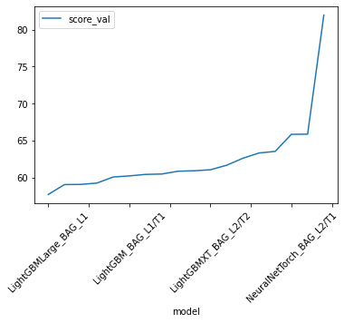

```python
# performance comparision
import matplotlib.pyplot as plt

result['score_val'] = result['score_val'].apply(func=lambda x: -x)

result.plot.line(x='model', y='score_val' )
plt.xticks(rotation=45)
```

```python
# Remember to set all negative values to zero
predictions = predictor_new_hpo.predict(new_test)
```

```python
# Same submitting predictions
submission_new_hpo = predictions.to_frame()
submission_new_hpo['datetime'] = test['datetime']
submission_new_hpo = submission_new_hpo[['datetime', 'count']]
```

```python
submission_new_hpo.loc[submission_new_hpo['count'] < 0, 'count'] = 0
```

```python
submission_new_hpo.to_csv("submission_new_hpo.csv", index=False)
```

```python
!kaggle competitions submit -c bike-sharing-demand -f submission_new_hpo.csv -m "new features with hyperparameters"
```

```
Successfully submitted to Bike Sharing Demand
```

```python
!kaggle competitions submissions -c bike-sharing-demand | tail -n +1 | head -n 10
```

```
fileName                     date                 description                        status    publicScore  privateScore
---------------------------  -------------------  ---------------------------------  --------  -----------  ------------
submission_new_hpo.csv       2022-06-21 18:28:35  new features with hyperparameters  complete  0.51008      0.51008
submission_new_hpo.csv       2022-06-14 16:59:07  new features with hyperparameters  complete  0.61736      0.61736
submission_new_hpo.csv       2022-06-14 16:57:06  new features with hyperparameters  error
submission_new_features.csv  2022-06-14 16:07:31  new features                       complete  0.47442      0.47442
submission.csv               2022-06-14 10:24:10  first raw submission               complete  1.80659      1.80659
```